# Climate Trend Analysis

**Climate Trend Analysis** Knoxville, TN

## **Daily and Monthly Climate Data**

#### **Locally weighted smoothing**

A nonparametric locally-weighted (loess) regression was used to measure changes in daily temperature values for each residence bin to illustrate potential trends over the three specified periods. Loess method is nonparametric because assumptions have not been made about the distribution of the data. The analysis incorporates a smoothing procedure to produce a trendline of the distribution, which compares the distance of individual data points to the overall mean of the dataset. The resulting trendline can indicate whether distinct changes (increases or decreases) are visible overall in the dataset, as well as whether the loess function is overfitting the data. Scatterplots were produced to reflect statistical aspects (maximum, mean, and minimum) of the climate variables. The climate variables examined in this study were summer temperature (June-July-August), summer heat index (JJA), and winter temperature (December-January-February). Overall, nine (9) climate variables were assessed for each of the three (3) Knoxville residence bins.

##### **Short-term residents** (2005–2016)

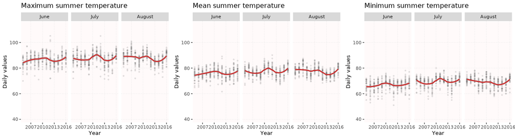

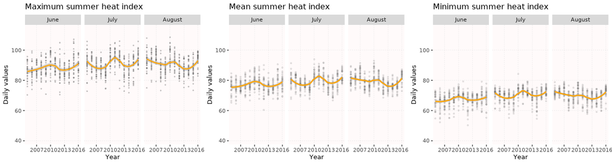

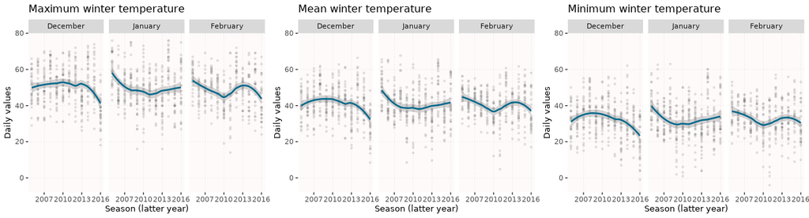

##### **Medium-term residents** (1982–2016)

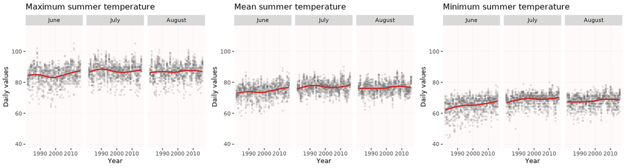

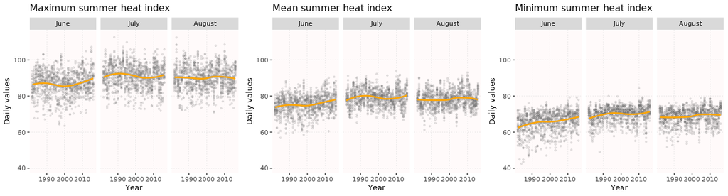

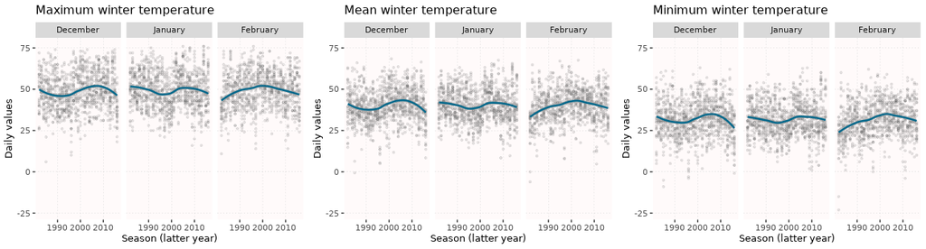

##### **Long-term residents** (1957–2016)

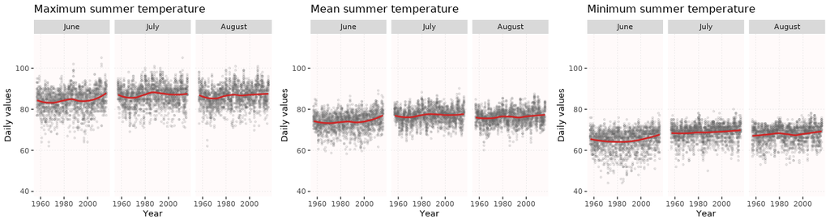

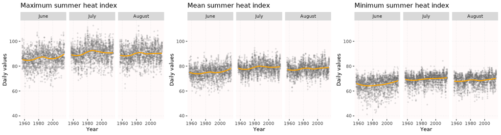

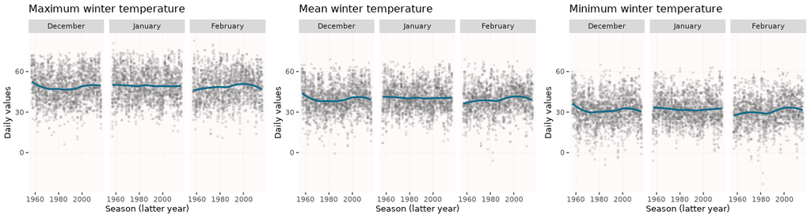

#### **Mann-Kendall trend test: Maximum, mean, & minimum daily climate**

A Mann-Kendall (M-K) trend test was run for the maximum, mean, and minimum values for the summer temperature, summer heat index, and winter temperature. The results are provided in the table below: the Kendall tau (τ) coefficient and its affiliated $p$-value reflect the the possible presence of a trend in the values over the dataset and its statistical significance, respectively. The `MannKendall` function from the `'Kendall'` package was employed in R for this test. This `function(x)` only considers the variable being measured, and does not incorporate an explicit dependent variable. Instead, the range of $y$ views the dataset without grouping it by units of time, so the function simply evaluates how the values change from data point to data point. As a result, $n$ reflects the number of observations present in the dataset all together, at times leading to small Kendall τ values. A Theil-Sen slope estimator is then applied to determine the slope of the trend; we used the `theil_sen_slope` function from the `'mkac'` package in R.

##### **Short-term residents** (2005–2016)

| Variable | Kendall $\tau$* | $p$ value | Theil Sen slope |
| --- | --- | --- | --- |
| **Summer temperatures** |  |  |  |
| Max | –0.005 | 0.804 | 0 |
| Mean | –0.006 | 0.768 | –0.000113344 |
| Min | 0.028 | 0.178 | 0 |
| **Summer heat index** |  |  |  |
| Max | 0.013 | 0.509 | 0.000381865 |
| Mean | 0.003 | 0.897 | 0.000068 |
| Min | 0.027 | 0.190 | 0.000437262 |
| **Winter temperatures** |  |  |  |
| Max | –0.097*** | 0.000 | –0.005329744 |
| Mean | –0.110*** | 0.000 | –0.005341051 |
| Min | –0.110*** | 0.000 | –0.005454545 |

Significance levels ( $p$ < * 0.05, ** 0.01, *** 0.001 or less) are provided.

##### **Medium-term residents** (1982–2016)

| Variable | Kendall $\tau$* | $p$ value | Theil Sen slope |
| --- | --- | --- | --- |
| **Summer temperatures** |  |  |  |
| Max | 0.033** | 0.006 | 0 |
| Mean | 0.077*** | 0.000 | 0.000516949 |
| Min | 0.129*** | 0.000 | 0.000798065 |
| **Summer heat index** |  |  |  |
| Max | 0.003 | 0.810 | 0 |
| Mean | 0.055*** | 0.000 | 0.000459713 |
| Min | 0.114*** | 0.000 | 0.000843944 |
| **Winter temperatures** |  |  |  |
| Max | 0.023 | 0.055 | 4.87E-05 |
| Mean | 0.040*** | 0.001 | 0.000661502 |
| Min | 0.046*** | 0.000 | 0.000708915 |

Significance levels ( $p$ < * 0.05, ** 0.01, *** 0.001 or less) are provided.

##### **Long-term residents** (1957–2016)

| Variable | Kendall $\tau$* | $p$ value | Theil Sen slope |
| --- | --- | --- | --- |
| **Summer temperatures** |  |  |  |
| Max | 0.090*** | 0.000 | 0.000387514 |
| Mean | 0.087*** | 0.000 | 0.000332523 |
| Min | 0.084*** | 0.000 | 0.000265552 |
| **Summer heat index** |  |  |  |
| Max | 0.086*** | 0.000 | 0.000553613 |
| Mean | 0.096*** | 0.000 | 0.000458659 |
| Min | 0.101*** | 0.000 | 0.000435396 |
| **Winter temperatures** |  |  |  |
| Max | 0.019* | 0.037 | 0 |
| Mean | 0.028** | 0.002 | 0.000273159 |
| Min | 0.024** | 0.009 | 0 |

Significance levels ( $p$ < * 0.05, ** 0.01, *** 0.001 or less) are provided.

> **Analyzing results:**
> - How does temperature/heat index trend over time?
> - Overall, were there trends detected by bin? If so, what were they?
> - Were any of the trends statistically significant?
> - How great was the rate of change (slope) of the statistically significant trends?
> - In general, have hot temperatures increased/decreased over period of residence?
> - Have cold temperatures been increasing/decreasing over the period of residence?

$~$

## **Extreme climate data**

To adequately assess whether unusual or ‘extreme’ Knoxville weather has increased or decreased in frequency, we isolated what we considered as ‘extreme’. These events are defined as values that exceeded the 95<sup>th</sup> percentile in the case of summer data, and values that fell below the 5<sup>th</sup> percentile for winter data. These extreme datasets include values that are equal to the 95<sup>th</sup> and 5<sup>th</sup> percentiles. We also focus on only four climate variables: maximum summer temperatures, maximum heat index, maximum winter temperatures, and minimum winter temperatures. The 95<sup>th</sup> and 5<sup>th</sup> percentile threshold of each climate variable were calculated for the three residence bins. The ‘extreme’ events were grouped by year, producing annual frequency datasets that can demonstrate extreme climate behavior over time. Overall, four (4) extreme climate variables were assessed for each of the three (3) Knoxville residence bins. These datasets are used for any remaining analyses, which are shown below.

#### **Histograms**

We begin to address whether extreme temperatures are occurring more frequently through exploratory data analysis. Extreme values (> 95<sup>th</sup> or < 5<sup>th</sup> percentile) of four climate variables were plotted to show frequency distributions for each of the three residence bins. Histograms were generated at `binwidth = 1.6` and overlaid with a `stat_density` function to better ascertain the shape of the underlying distribution. For referencing purposes, the total count of observations (days that experienced an extreme temperature/heat event) and number of years in the dataset ($n$) are provided for each plot. The general shape across distributions appears to be Poisson. This determination is not unexpected, as extreme values (or tails) taken from an overall dataset and graphed as standalone values will generally produce a Poisson distribution. Note the histograms shown here though do not include the years reporting a zero (0) value, as the goal of this initial exercise is to assess how the frequency of extreme climate values has been fluctuating. Additionally, the zero values only represent a lack of extreme values in one individual year, as opposed to the number of days that did not observe extreme climate—the latter of which would dominate the graph and potentially eclipse the underlying distribution. Even when zero years are included in the total observation count, the resulting shape resembles a negative binomial distribution. Negative binomial is closely related to Poisson, yet more forgiving of zero-inflated datasets in terms of their variance. Once we’ve assessed the general distribution shape, we can progress to evaluating the annual frequency distribution of the extreme data, shown in the next section.

##### **Short-term residents** (2005–2016)

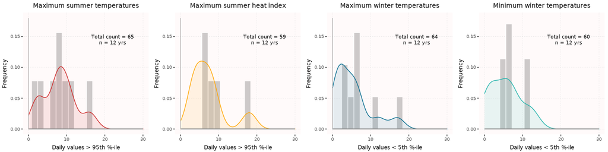

##### **Medium-term residents** (1982–2016)

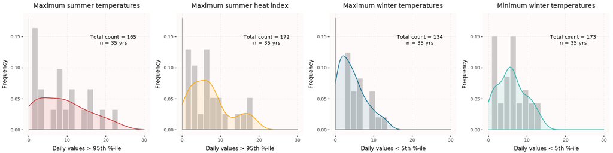

##### **Long-term residents** (1957–2016)

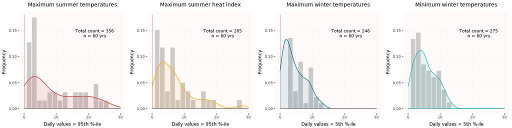

*Years that did not experience extreme temperature events were not included in datasets.

#### **Time series plots**

Times series plots were also produced to visualize annual frequency of extreme climate events over each of the residence periods. To help pinpoint any distinct trends (or lack thereof), a basic trendline was fashioned for each plot. The trendline was produced with `geom_smooth` from the `'ggplot2'` package, and because we are viewing frequency of count data, we delineated the `‘glm’` method for estimation. Although the histograms suggest a Poisson distribution, the plots also left out the years with frequency values of 0 when they were produced. However, when those missing years are included in the histogram (not shown), the distribution takes a distinct negative binomial shape. As the time series analysis includes years with 0, a negative binomial distribution is assumed and the `geom_smooth()` method is specified as `‘glm.nb’`. The resulting trendlines therefore reflect a negative binomial regression model that was fit to each dataset.

##### **Short-term residents** (2005–2016)

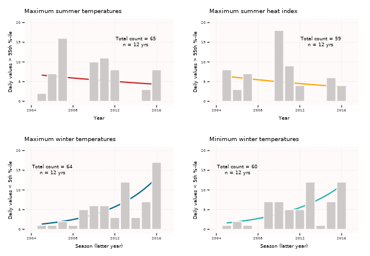

##### **Medium-term residents** (1982–2016)

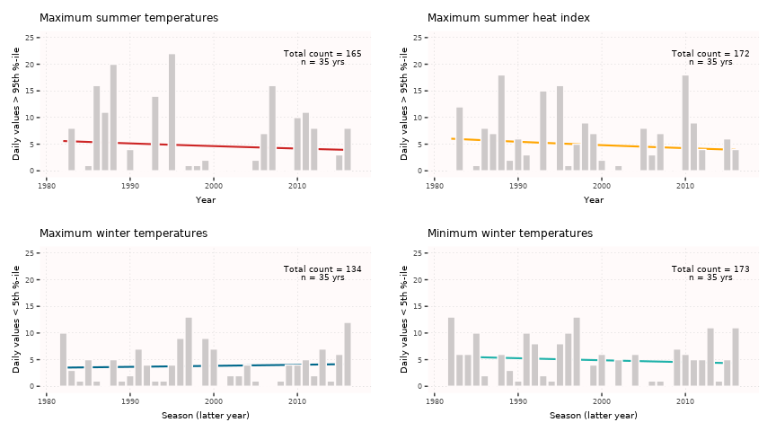

##### **Long-term residents** (1957–2016)

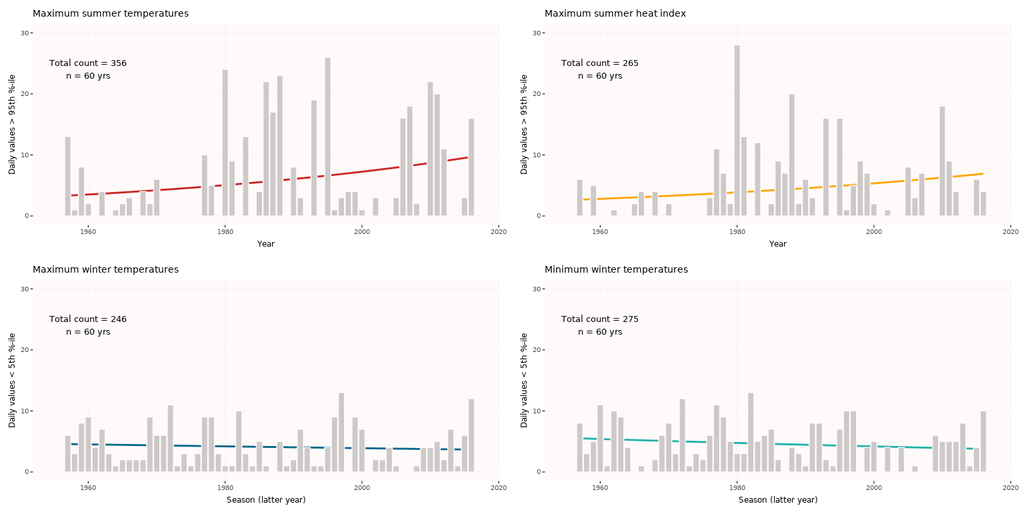

#### **Mann-Kendall trend test: Annual frequency of extreme climate**

##### **Short-term residents** (2005–2016)

[output not shown]

Significance levels ( $p$ < * 0.05, ** 0.01, *** 0.001 or less) are provided.

##### **Medium-term residents** (1982–2016)

| Variable | Kendall $\tau$ | $p$ value | Theil Sen slope | $n$ | No. obs |
| --- | --- | --- | --- | --- | --- |
| **Above 95th %-ile** |  |  |  |  |  |
| Max summer temps | 0 | 0.988 | 0 | 35 | 165 |
| Max summer HI | –0.07226891 | 0.543 | 0 | 35 | 172 |
| **Below 5th %-ile** |  |  |  |  |  |
| Max winter temps | 0.04369748 | 0.719 | 0 | 35 | 134 |
| Min winter temps | –0.08067227 | 0.501 | 0 | 35 | 173 |

Significance levels ( $p$ < * 0.05, ** 0.01, *** 0.001 or less) are provided.

##### **Long-term residents** (1957–2016)

| Variable | Kendall $\tau$ | $p$ value | Theil Sen slope | $n$ | No. obs |
| --- | --- | --- | --- | --- | --- |
| **Above 95th %-ile** |  |  |  |  |  |
| Max summer temps | 0.08870056 | 0.308 | 0 | 60 | 356 |
| Max summer HI | 0.1175141 | 0.173 | 0 | 60 | 265 |
| **Below 5th %-ile** |  |  |  |  |  |
| Max winter temps | –0.09152542 | 0.300 | 0 | 60 | 246 |
| Min winter temps | –0.08418079 | 0.342 | –0.02173913 | 60 | 275 |

Significance levels ( $p$ < * 0.05, ** 0.01, *** 0.001 or less) are provided.

> **Analyzing results:**
> - How do extreme temperature/heat index events trend over time?
> - Overall, were there trends detected by bin? If so, what were they?
> - Were any of the trends statistically significant?
> - How great was the rate of change (slope) of the statistically significant trends that were detected?
> - In general, have extreme or unusually hot temperatures increased/decreased over period of residence?
> - Have cold temperatures been increasing/decreasing over the period of residence?

#doneyalls